# Paperless Learning Journey

## Introduction

In the previous Project 2, I have been logging my **paperless study sessions**. I got the idea of logging it because in my country, students usually have a huge amount of homework to complete. I still remember that at graduation, I stacked all the assignments I had written, and the height was **much taller** than I was at the time, imagine how much paper and ink that was! So, when I saw the requirement to log something for Project 2, I had the idea of logging paperless learning.

Overall, I logged:

- Course
- Content Type (notes, exercises, tutorial worksheets, etc.)
- Number of pages
- Ink density
- Time spent

This term I only have three courses need to really take notes, they are COMPSCI 120, MATHS 130 and STATS 125. In terms of the results, this not only shows how many paper/pens I have saved, but also reflects my **study habits**.

## The Digital Workload

My first question was simple: *where is all my time going?*

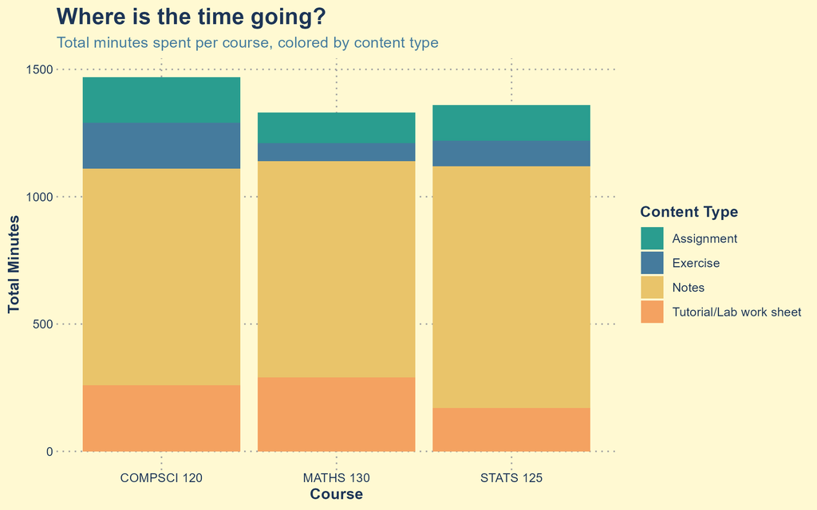

A stacked bar chart showing total minutes spent per course, with COMPSCI 120 being the highest. The majority of time for all courses is spent on Notes.

Looking at the total minutes spent per course, **COMPSCI 120** takes the slight lead. However, the most striking finding is the huge block of yellow across all three courses. Taking general **Notes** costs the majority of my study time, which makes sense, considering a lot of time is spent listening to lectures and taking notes.

## Consistent Writing Speed

*There is no way to have **consistent writing speed** for different courses right? Right?*

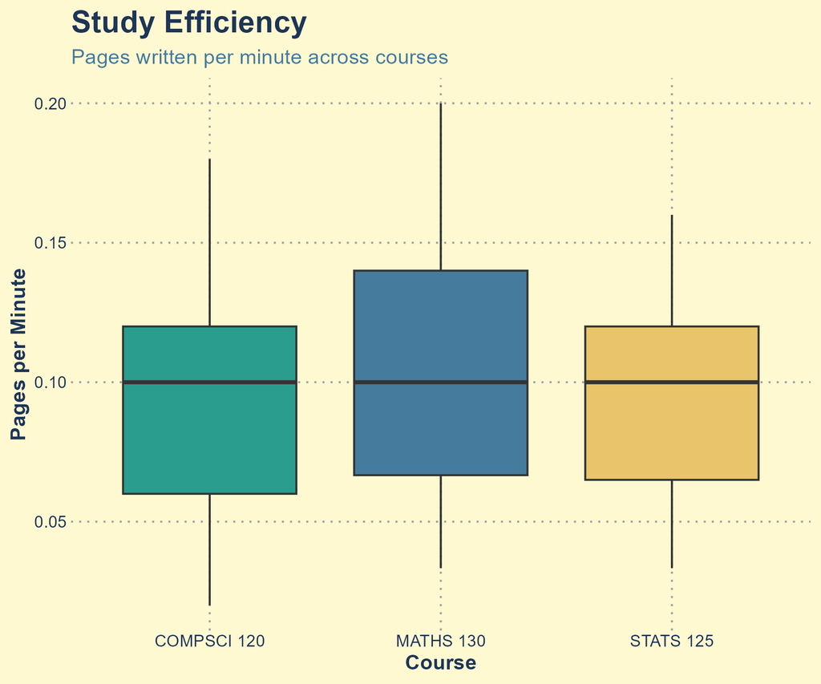

A box plot showing writing speed for each course, in the pages per minutes, with all three courses have the exactly same median of 0.1. While MATHS 130 has the highest speed.

Next, I looked at my writing speed (pages per minute). Interestingly, although the courses are very different, my median writing speed is the **same** across all three courses, which is **0.10 pages per minute**. While **MATHS 130** has the **highest** speed, likely due to having limit time to take lots of notes, my baseline writing speed is consistent.

## Peak hours in the week

*When am I actually glued to my screen?*

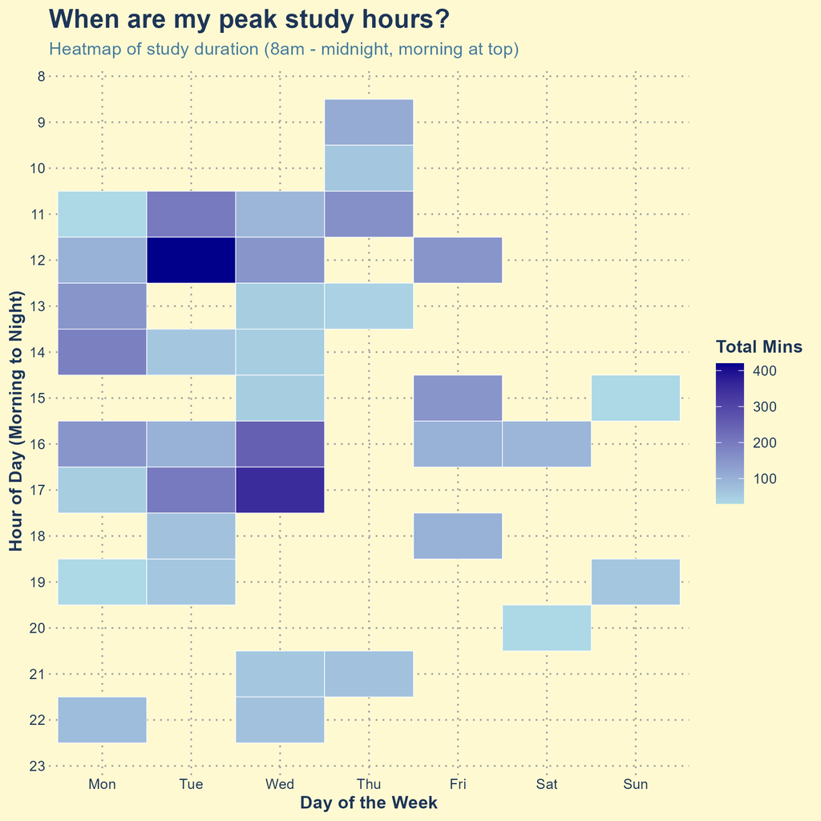

## Cumulative Effort

*This title definitely make sense.*

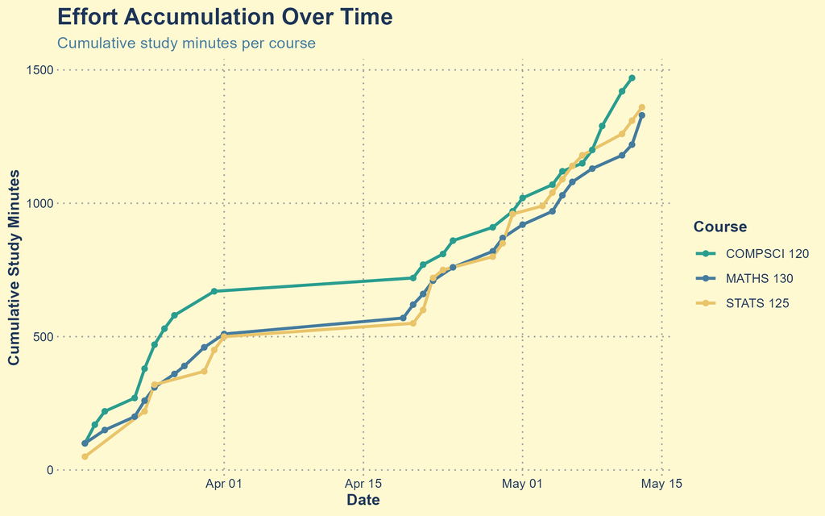

A line chart showing the cumulative study time for each course increasing over time. There is a climb of cumulative time from late March to April 1st, then flat line from April 1st to late Aprile, climb again from late April.

This line chart tracks the cumulative build-up of my study time, and it tells a very clear story. You can see a steep, steady **climb** of effort throughout late March. However, there is a very obvious, **flat** line in the middle of the graph. This flat line perfectly captures the **mid-semester break**! Then lines steeply climb again as classes resumed.

## Ink Density vs Pages

*My favourite plot, as they said, “Save the Best for Last”.*

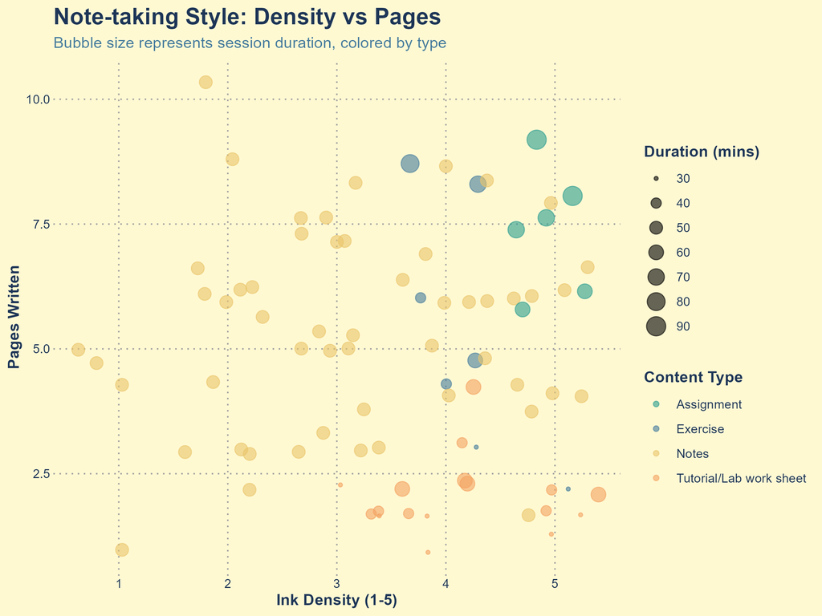

A jitter plot comparing ink density on the x-axis against pages written on the y-axis. The size of each bubble represents the duration in minutes, and the color represents the content type. The chart shows some clusters: Assignments (green) are mostly in the top right, showing high page counts and high ink density. Tutorial and Lab sheets (orange) cluster in the bottom right, showing low page counts but high density. Notes (yellow) are the most numerous and are widely scattered across the chart. Exercise (blue) are mostly in the top middle, showing they are less density than assignment.

Finally, I wanted to see what kind of work uses the most ink, paper and time. This jitter plot shows beautiful **clusters** based on the type of content.

- Tutorial/Lab worksheets (orange): Clustered in the **bottom right**. They don’t take up many pages, but the pages are completely packed with **dense ink**.
- Assignments (green): Clustered in the **top right**. These are the heavy **page counts** and high **ink density** at the same time. They usually have a high **duration**.
- Notes (yellow): Scattered **widely**, but generally lower in density.
- Exercise (blue): Clustered in the **top middle**, they are less density than assignment.